# Metals — metamodel pipeline

This notebook covers the metals — gold, silver, copper and platinum. Of the three asset classes this is the cleanest expression of the signal's contrarian construction: every metal reverses against its prior move. That tidiness at the signal level does not, however, translate into a strong metamodel edge. The most interesting tension in the whole study lives here — a feature set that looks predictive in cross-validation can still collapse to chance out of sample, and gold is the clearest example. The sections below follow that thread from the signal audit to the locked models and their honest hold-out scores.

**Universe.** `gc1s`, `si1s`, `hg1s`, `pl1s` (4 contracts).

**Reading guide.** The notebook runs top to bottom against committed artifacts; no model is retrained. Each stage loads its result files and embeds the figures already produced by the pipeline. Section order mirrors the marking scheme in `reports/harry/00-context.md`: data, signal, labelling, features, model selection, cluster importance, evaluation.

*Source of truth.* Where a number appears it is loaded from a file in this cell's output, not transcribed from prose; the few places where the committed data and the written reports disagree are flagged inline.

```python
CLASS = 'metals'
INSTS = ['gc1s', 'si1s', 'hg1s', 'pl1s']
NAMES = {'gc1s': 'Gold (GC)', 'si1s': 'Silver (SI)', 'hg1s': 'Copper (HG)', 'pl1s': 'Platinum (PL)'}

from pathlib import Path
import pandas as pd
import warnings
warnings.filterwarnings("ignore")
from IPython.display import Image, display, Markdown


def _repo_root() -> Path:
    here = Path.cwd().resolve()
    for q in [here, *here.parents]:
        if (q / "pyproject.toml").exists():
            return q
    return here


REPO = _repo_root()
OUT = REPO / "src/stml/new_work/outputs"
RESULTS = REPO / "results"
REPORTS = REPO / "reports"
DATA = REPO / "data"


def show(path, width=1000):
    p = Path(path)
    if p.exists():
        display(Image(str(p), width=width))
    else:
        print(f"[missing figure] {p}")


def load(path) -> pd.DataFrame:
    p = Path(path)
    if p.exists():
        return pd.read_csv(p)
    print(f"[missing data] {p}")
    return pd.DataFrame()


def table(df, n=None, caption=None):
    if df is None or len(df) == 0:
        print("[empty table]")
        return
    d = df.head(n) if n else df
    sty = d.style.format(precision=4).hide(axis="index")
    if caption:
        sty = sty.set_caption(caption)
    display(sty)
```

## 1. Data and cleaning

The price history runs from 1990, while the primary signal is released only over 2020-01-03 to 2022-06-30; the sealed test period sits beyond the embargo. Loading goes through `stml.io`, and the missing-data policy — keep zero-volume weekday settles, drop weekend and out-of-bounds rows — is documented in `reports/missing-data-report.md` and implemented in `stml.na_checks`. The coverage table below is computed directly from `data/ohlcv_data.csv` for this class's contracts.

```python
ohlcv = load(DATA / "ohlcv_data.csv")
sub = ohlcv[ohlcv["instrument"].isin(INSTS)]
cov = (sub.groupby("instrument")
          .agg(first_date=("date", "min"), last_date=("date", "max"), n_rows=("date", "size"))
          .reindex(INSTS).reset_index())
table(cov, caption=f"{CLASS.title()} — OHLCV coverage (data/ohlcv_data.csv)")
```

Metals — OHLCV coverage (data/ohlcv_data.csv)

| instrument | first_date | last_date | n_rows |
| --- | --- | --- | --- |
| gc1s | 1990-01-02 | 2022-06-30 | 8171 |
| si1s | 1990-01-02 | 2022-06-30 | 8172 |
| hg1s | 1990-01-02 | 2022-06-30 | 8172 |
| pl1s | 1990-01-02 | 2022-06-30 | 8169 |

## 2. Signal characterisation

Metals are the textbook case. All four contracts load negatively on the trailing one-day return and positively on the forward return, so the signal is uniformly short-horizon mean reversion with no awkward exceptions of the kind crude introduces in energy. If signal cleanliness alone decided the matter, metals would be the strongest class. The model section shows why it is not: a well-behaved signal is necessary but not sufficient for the metamodel to add value.

```python
sd = load(RESULTS / "harry/signal_direction.csv")
if not sd.empty:
    want = ["instrument", "n_bets", "corr_fwd_1", "corr_fwd_5", "corr_trail_1", "corr_contemp_0"]
    cols = [c for c in want if c in sd.columns]
    rows = sd[sd["instrument"].isin(INSTS)][cols].set_index("instrument").reindex(INSTS).reset_index()
    table(rows, caption=f"{CLASS.title()} — signal direction (results/harry/signal_direction.csv)")
```

Metals — signal direction (results/harry/signal_direction.csv)

| instrument | n_bets | corr_fwd_1 | corr_fwd_5 | corr_trail_1 | corr_contemp_0 |
| --- | --- | --- | --- | --- | --- |
| gc1s | 168 | 0.1291 | 0.0152 | -0.0870 | -0.0153 |
| si1s | 578 | 0.0567 | 0.0018 | -0.1434 | -0.1577 |
| hg1s | 628 | 0.1218 | 0.0215 | -0.1092 | -0.1793 |
| pl1s | 557 | 0.0709 | 0.0243 | -0.1475 | -0.1870 |

## 3. Labelling

Each signal is turned into a binary meta-label by the triple-barrier method of López de Prado (2018, ch. 3): an upper (profit-taking) and lower (stop-loss) barrier are placed in units of a causal volatility estimate, a vertical barrier caps the holding period, and the label records whether taking the bet would have paid. Overlapping events are down-weighted by average uniqueness (López de Prado, 2018, ch. 4).

The submitted metamodel is trained and scored on the **team-provided labels** in `data/meta/triple_barrier_labels.csv`. The barrier geometry is tuned per instrument and held constant within each: the stop-loss sits at one quarter of the volatility estimate for every contract (`sl = 0.25`), while the profit-taking multiple and the vertical-barrier horizon are set per instrument — some contracts take a tight one-day barrier, others a wider profit target held for two to four weeks. The exact geometry is read from the data and shown per instrument below rather than quoted, because the values differ across the universe.

Provenance is not assumed: every locked out-of-sample prediction in `metamodel_predictions.csv` matches these labels exactly — 1373 of 1373 rows agree on the binary label after joining on instrument and date — so this file, not any other, is the label set the model was built on.

*Provenance note.* An earlier exploration documented in `reports/harry/02-labels.md` and persisted to `results/harry/events.csv` used a uniform ten-day barrier; it produces the same number of events (one per signal date) but different labels, and it was superseded by the per-instrument team labels used here. The report is retained as a record of that exploration.

```python
lab = load(DATA / "meta/triple_barrier_labels.csv")
lab = lab[lab["instrument"].isin(INSTS)]
if not lab.empty:
    # Per-instrument barrier geometry + event statistics, straight from the team labels.
    g = (lab.groupby("instrument")
            .agg(pt=("pt", "first"), sl=("sl", "first"), h=("h", "first"),
                 n_events=("label", "size"), label1_share=("label", "mean"),
                 mean_sigma=("sigma", "mean"))
            .reindex(INSTS).reset_index())
    table(g, caption=f"{CLASS.title()} — per-instrument barriers and labels (data/meta/triple_barrier_labels.csv)")
    if "partition" in lab.columns:
        part = (lab.groupby(["instrument", "partition"]).size()
                   .unstack(fill_value=0).reindex(INSTS).reset_index())
        table(part, caption="Events per train / validation / test partition")
    print(f"Total labelled events for {CLASS}: {len(lab):,}  |  label==1 share: {lab['label'].mean():.3f}")
```

Metals — per-instrument barriers and labels (data/meta/triple_barrier_labels.csv)

| instrument | pt | sl | h | n_events | label1_share | mean_sigma |
| --- | --- | --- | --- | --- | --- | --- |
| gc1s | 1.0000 | 0.2500 | 15 | 160 | 0.5000 | 0.0118 |
| si1s | 0.7500 | 0.2500 | 20 | 558 | 0.4140 | 0.0217 |
| hg1s | 1.0000 | 0.2500 | 10 | 618 | 0.4126 | 0.0148 |
| pl1s | 0.2500 | 0.2500 | 1 | 556 | 0.5396 | 0.0218 |

Events per train / validation / test partition

| instrument | test | train | val |
| --- | --- | --- | --- |
| gc1s | 22 | 118 | 20 |
| si1s | 97 | 340 | 121 |
| hg1s | 115 | 377 | 126 |
| pl1s | 104 | 339 | 113 |

```
Total labelled events for metals: 1,892  |  label==1 share: 0.458
```

## 4. Features

Predictors are grouped into causal families, all computed at the signal date and predictive of the next-day label, so none peeks into the future. The micro families (`reports/harry/03-features.md`) cover the signal's own trajectory, conditional risk, information-theoretic dependence, fixed microstructure proxies, cross-asset structure, an optional wavelet decomposition and a concept-drift discriminator. A macro block of thirty-one rolling, standardised series (`reports/harry/03-6-macro-features.md`) adds volatility, rates, credit, dollar, commodity-fundamental and growth context. Two hidden-Markov regime blocks — per-instrument volatility (`hmm_vol`) and a global risk-on/risk-off state (`hmm_macro`) — are fit only on pre-sample data and then frozen, so they are train-fitted rather than leaking. Features are tagged `E` (purely causal) or `TF` (train-fitted on pre-sample) accordingly.

```python
# The feature matrix is built by the pipeline; here we confirm the frozen HMM
# regime features are present for this class's instruments.
for fn in ["features_hmm_vol.csv", "features_hmm_macro.csv"]:
    f = load(REPO / "src/stml/new_work" / fn)
    if not f.empty and "instrument" in f.columns:
        n = f[f["instrument"].isin(INSTS)].shape[0]
        print(f"{fn}: {n:,} rows for {CLASS} instruments | columns: {list(f.columns)}")
    elif not f.empty:
        print(f"{fn}: {f.shape[0]:,} rows | columns: {list(f.columns)}")
```

```
features_hmm_vol.csv: 2,512 rows for metals instruments | columns: ['date', 'instrument', 'hmm_vol_p0_calm', 'hmm_vol_p2_turbulent', 'hmm_vol_next_turbulent', 'hmm_vol_entropy']
features_hmm_macro.csv: 2,580 rows for metals instruments | columns: ['date', 'instrument', 'hmm_macro_p0', 'hmm_macro_next_riskoff', 'hmm_macro_entropy']
```

## 5. Model selection

Each instrument runs a horse race across penalised logistic regression, a random forest, gradient boosting and a small multi-task network, scored by combinatorial purged cross-validation (six groups, two held out, fifteen paths) with per-instrument purging and embargo. Feature variants (full, pruned, reduced) are compared, and the simplest variant within one cross-path standard error of the best is locked **before** the out-of-sample window is touched. The cross-validation runs on the training partition only; the sealed test (after 2021-10-20) is scored once, with the locked choice fixed.

Random forests win across the metals, and the precious names are pooled where their individual event counts are thin. The cautionary result is gold: a reduced feature set lifts its cross-validated AUC above 0.56, yet the same model drops below 0.5 out of sample. That pattern — strong in development, chance in the hold-out — is the signature of fitting to the top few importance clusters rather than to anything that generalises. The locked picks below are honest about which metals clear their confidence bound and which do not.

Metals — champion model and signal verdict (selection_table.csv)

| instrument | best_model | best_auc | lower_ci | signal |
| --- | --- | --- | --- | --- |
| gc1s | rf | 0.4866 | 0.3734 | False |
| si1s | rf | 0.5400 | 0.4762 | False |
| hg1s | rf | 0.5463 | 0.5058 | True |
| pl1s | rf | 0.5697 | 0.5396 | True |

Locked feature variant per instrument (1SE rule, train-only)

| inst | locked_variant |
| --- | --- |
| gc1s | reduced |
| si1s | reduced |
| pl1s | reduced |
| hg1s | reduced |

**Gold (GC) — `gc1s` cross-validated variants**

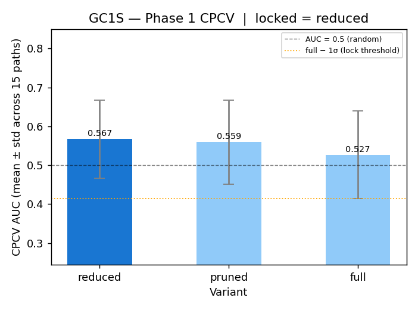

**Silver (SI) — `si1s` cross-validated variants**

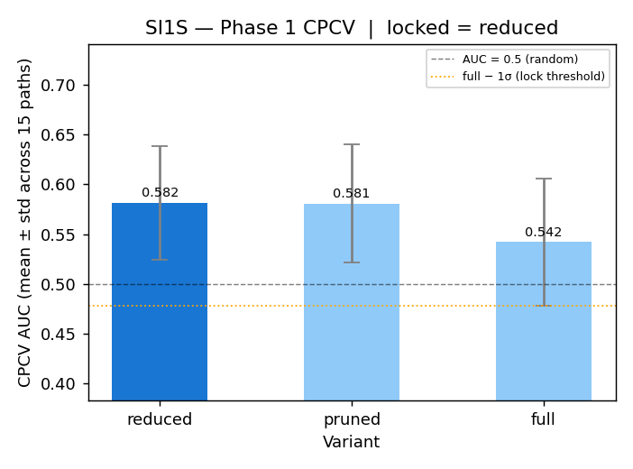

**Copper (HG) — `hg1s` cross-validated variants**

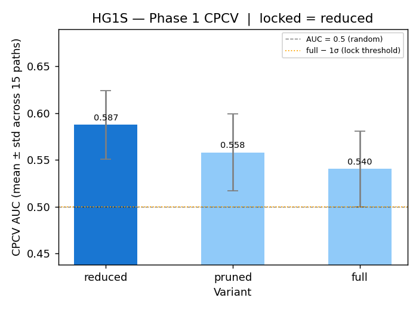

**Platinum (PL) — `pl1s` cross-validated variants**

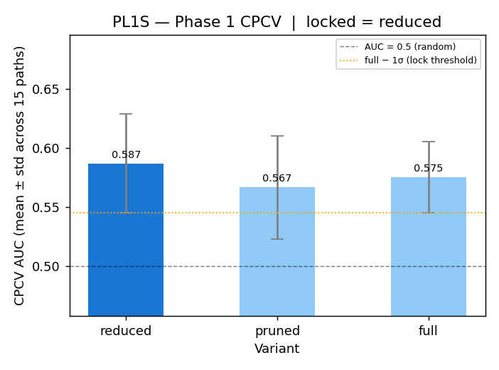

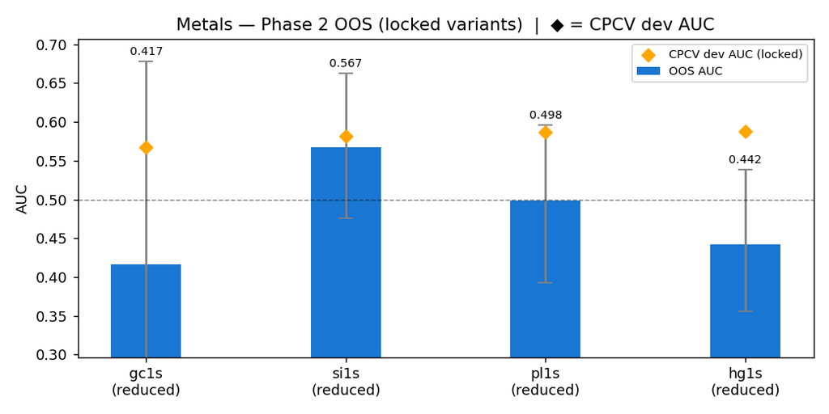

Out-of-sample AUC — locked variants only

| inst | variant | auc | auc_ci_lo | auc_ci_hi | n_test |
| --- | --- | --- | --- | --- | --- |
| gc1s | reduced | 0.4167 | 0.1665 | 0.6786 | 23 |
| si1s | reduced | 0.5668 | 0.4759 | 0.6628 | 144 |
| pl1s | reduced | 0.4984 | 0.3933 | 0.5958 | 148 |
| hg1s | reduced | 0.4421 | 0.3559 | 0.5389 | 164 |

```python
mc = OUT / "model_comparison" / CLASS
sel = load(OUT / "model_comparison/selection_table.csv")
locked = load(mc / "locked_picks.csv")
cpcv = load(mc / "cpcv_results.csv")
oos = load(mc / "oos_results.csv")

if not sel.empty:
    # NB: selection_table's own 'n_events' is a derived training-sample count, not the
    # triple-barrier event count reported in section 3, so it is omitted here to avoid a
    # misleading clash.
    keep = [c for c in ["instrument", "best_model", "best_auc", "lower_ci", "signal"]
            if c in sel.columns]
    sc = sel[sel["instrument"].isin(INSTS)][keep].set_index("instrument").reindex(INSTS).reset_index()
    table(sc, caption=f"{CLASS.title()} — champion model and signal verdict (selection_table.csv)")

if not locked.empty:
    table(locked, caption="Locked feature variant per instrument (1SE rule, train-only)")

for inst in INSTS:
    display(Markdown(f"**{NAMES[inst]} — `{inst}` cross-validated variants**"))
    show(mc / f"{inst}_cpcv_chart.png", width=760)

show(mc / "oos_summary_chart.png", width=820)

# Out-of-sample AUC for the locked variants only.
if not oos.empty and not locked.empty:
    lk = dict(zip(locked["inst"], locked["locked_variant"]))
    mask = oos.apply(lambda r: lk.get(r["inst"]) == r["variant"], axis=1)
    keep = [c for c in ["inst", "variant", "auc", "auc_ci_lo", "auc_ci_hi", "n_test"] if c in oos.columns]
    table(oos[mask][keep], caption="Out-of-sample AUC — locked variants only")
```

## 6. Feature importance

Importance is read at the cluster level rather than per raw feature, because the predictors are correlated in blocks and per-feature scores would split credit arbitrarily across substitutes. Features are clustered on a rank-correlation distance; the dendrogram shows the block structure, mean-decrease-accuracy gives each cluster's drop, and a global SHAP or coefficient ranking resolves the within-cluster detail. Logistic champions are read through their coefficients, tree and network champions through SHAP.

Gold (GC) — `gc1s`

| instrument | asset_class | group | family | model_type | auc_mean | auc_std | lower_ci | signal | n_folds | n_sig_clusters |
| --- | --- | --- | --- | --- | --- | --- | --- | --- | --- | --- |
| gc1s | metals | precious | tree | rf | 0.4866 | 0.1132 | 0.3734 | False | 15 | 0 |

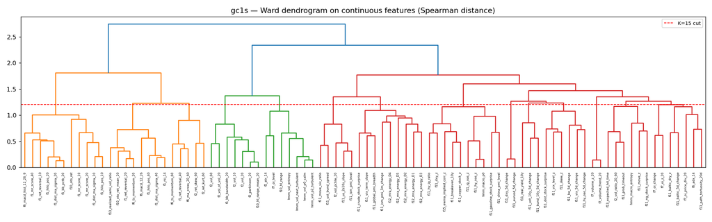

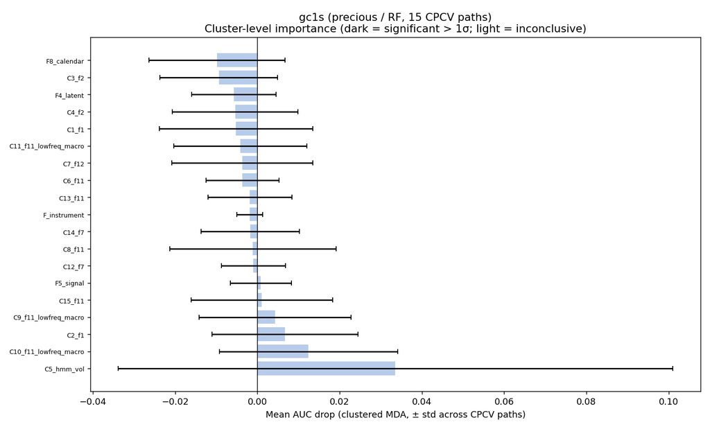

Top clusters by mean decrease in accuracy

| cluster | mean_drop | std_drop | significant |
| --- | --- | --- | --- |
| C5_hmm_vol | 0.0336 | 0.0674 | False |
| C10_f11_lowfreq_macro | 0.0124 | 0.0217 | False |
| C2_f1 | 0.0067 | 0.0178 | False |
| C9_f11_lowfreq_macro | 0.0043 | 0.0184 | False |
| C15_f11 | 0.0011 | 0.0172 | False |
| F5_signal | 0.0008 | 0.0074 | False |
| C12_f7 | -0.0010 | 0.0078 | False |
| C8_f11 | -0.0011 | 0.0202 | False |

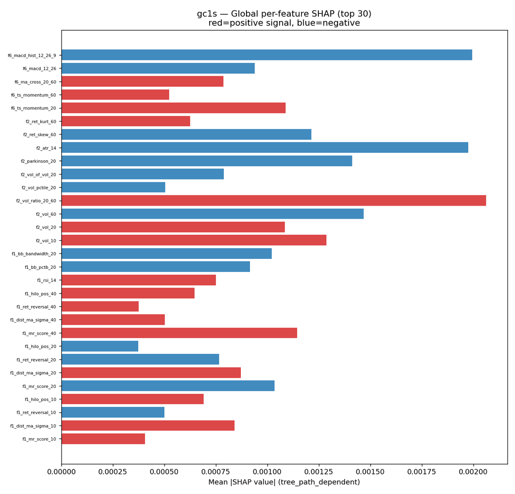

Top features by |SHAP|

| feature | shap_magnitude | shap_signed | mdi |
| --- | --- | --- | --- |
| hmm_vol_p0_calm | 0.0085 | -0.0007 | 0.0432 |
| hmm_vol_p2_turbulent | 0.0079 | -0.0017 | 0.0427 |
| hmm_vol_next_turbulent | 0.0079 | -0.0015 | 0.0463 |
| f11_ust_10y_5d_change | 0.0037 | 0.0001 | 0.0219 |
| hmm_vol_entropy | 0.0030 | -0.0006 | 0.0278 |
| f6_adx_14 | 0.0029 | -0.0018 | 0.0307 |
| f11_eurusd_5d_change | 0.0026 | 0.0000 | 0.0206 |
| f7_oi_z_20 | 0.0026 | -0.0005 | 0.0172 |
| f4_pc2 | 0.0025 | -0.0010 | 0.0187 |
| f11_copper_stock_z | 0.0023 | 0.0012 | 0.0109 |
| f4_pc1 | 0.0022 | -0.0001 | 0.0164 |
| f10_hl_range | 0.0022 | -0.0015 | 0.0104 |
| f11_dist_stock_surprise | 0.0021 | -0.0004 | 0.0122 |
| f2_vol_ratio_20_60 | 0.0021 | 0.0001 | 0.0111 |
| f6_macd_hist_12_26_9 | 0.0020 | -0.0002 | 0.0226 |

Silver (SI) — `si1s`

| instrument | asset_class | group | family | model_type | auc_mean | auc_std | lower_ci | signal | n_folds | n_sig_clusters |
| --- | --- | --- | --- | --- | --- | --- | --- | --- | --- | --- |
| si1s | metals | precious | tree | rf | 0.5400 | 0.0638 | 0.4762 | False | 15 | 0 |

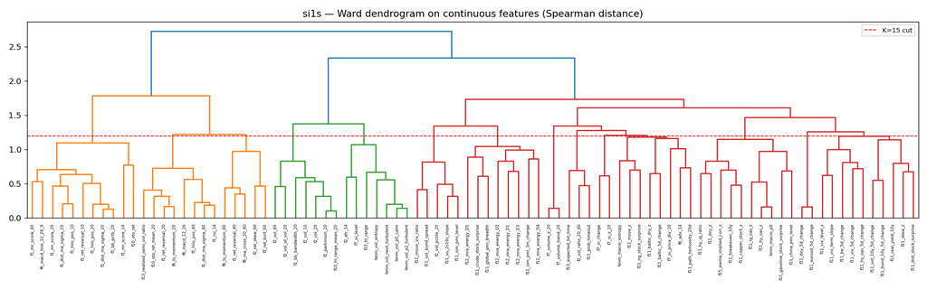

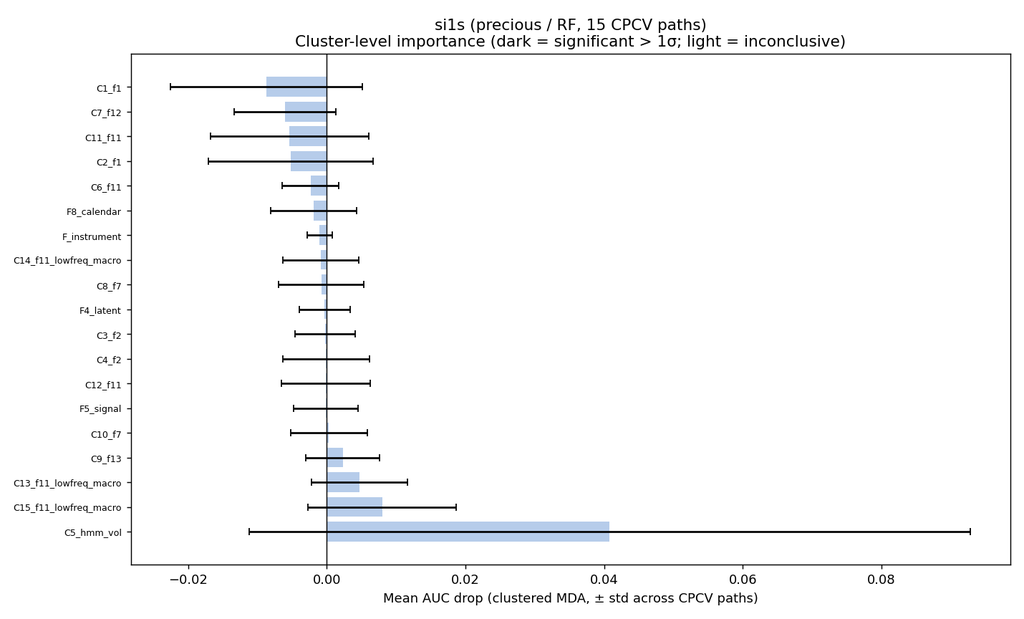

Top clusters by mean decrease in accuracy

| cluster | mean_drop | std_drop | significant |
| --- | --- | --- | --- |
| C5_hmm_vol | 0.0408 | 0.0520 | False |
| C15_f11_lowfreq_macro | 0.0080 | 0.0107 | False |
| C13_f11_lowfreq_macro | 0.0047 | 0.0069 | False |
| C9_f13 | 0.0023 | 0.0053 | False |
| C10_f7 | 0.0003 | 0.0055 | False |
| F5_signal | -0.0001 | 0.0046 | False |
| C12_f11 | -0.0001 | 0.0064 | False |
| C4_f2 | -0.0001 | 0.0062 | False |

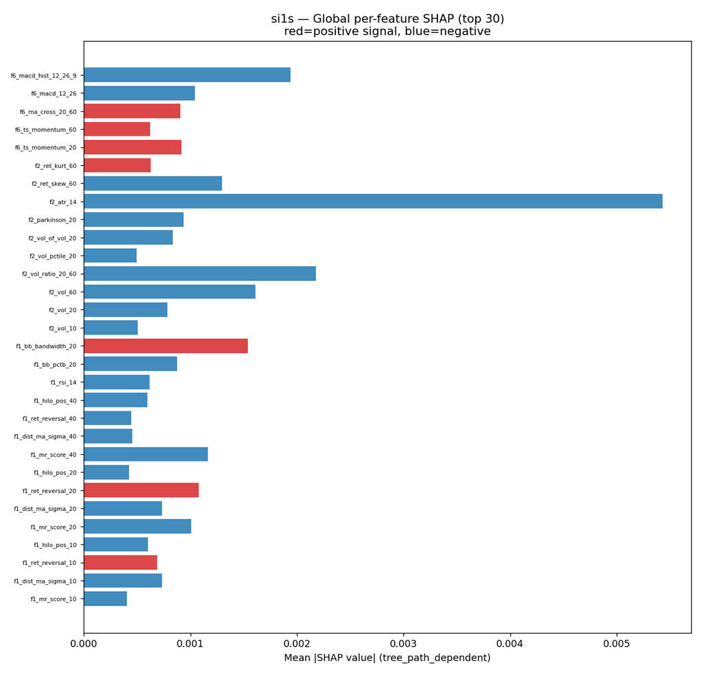

Top features by |SHAP|

| feature | shap_magnitude | shap_signed | mdi |
| --- | --- | --- | --- |
| hmm_vol_p0_calm | 0.0101 | -0.0040 | 0.0432 |
| hmm_vol_p2_turbulent | 0.0091 | -0.0036 | 0.0427 |
| hmm_vol_next_turbulent | 0.0088 | -0.0035 | 0.0463 |
| f2_atr_14 | 0.0054 | -0.0054 | 0.0301 |
| f11_ust_10y_5d_change | 0.0038 | -0.0005 | 0.0219 |
| hmm_vol_entropy | 0.0031 | -0.0009 | 0.0278 |
| f6_adx_14 | 0.0031 | -0.0017 | 0.0307 |
| f11_eurusd_5d_change | 0.0025 | -0.0002 | 0.0206 |
| f4_pc2 | 0.0025 | -0.0005 | 0.0187 |
| f7_oi_z_20 | 0.0025 | -0.0005 | 0.0172 |
| f11_copper_stock_z | 0.0023 | 0.0013 | 0.0109 |
| f2_vol_ratio_20_60 | 0.0022 | -0.0002 | 0.0111 |
| f11_bund_10y_5d_change | 0.0021 | -0.0002 | 0.0168 |
| f7_oi_level | 0.0021 | -0.0020 | 0.0163 |
| inst_si1s | 0.0019 | -0.0019 | 0.0061 |

Copper (HG) — `hg1s`

| instrument | asset_class | group | family | model_type | auc_mean | auc_std | lower_ci | signal | n_folds | n_sig_clusters |
| --- | --- | --- | --- | --- | --- | --- | --- | --- | --- | --- |
| hg1s | metals | hg1s | tree | rf | 0.5463 | 0.0405 | 0.5058 | True | 15 | 2 |

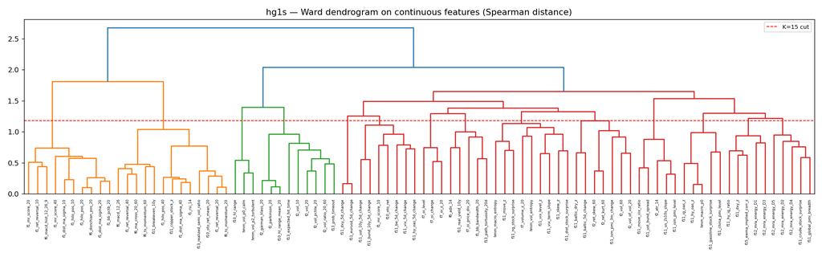

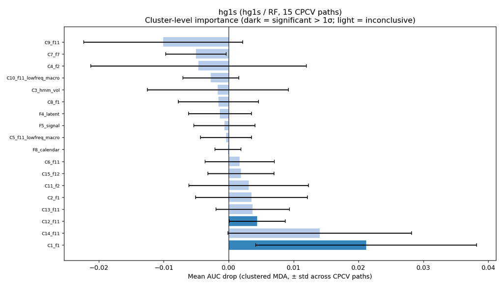

Top clusters by mean decrease in accuracy

| cluster | mean_drop | std_drop | significant |
| --- | --- | --- | --- |
| C1_f1 | 0.0212 | 0.0170 | True |
| C14_f11 | 0.0140 | 0.0141 | False |
| C12_f11 | 0.0044 | 0.0043 | True |
| C13_f11 | 0.0037 | 0.0057 | False |
| C2_f1 | 0.0035 | 0.0086 | False |
| C11_f2 | 0.0031 | 0.0092 | False |
| C15_f12 | 0.0019 | 0.0051 | False |
| C6_f11 | 0.0017 | 0.0054 | False |

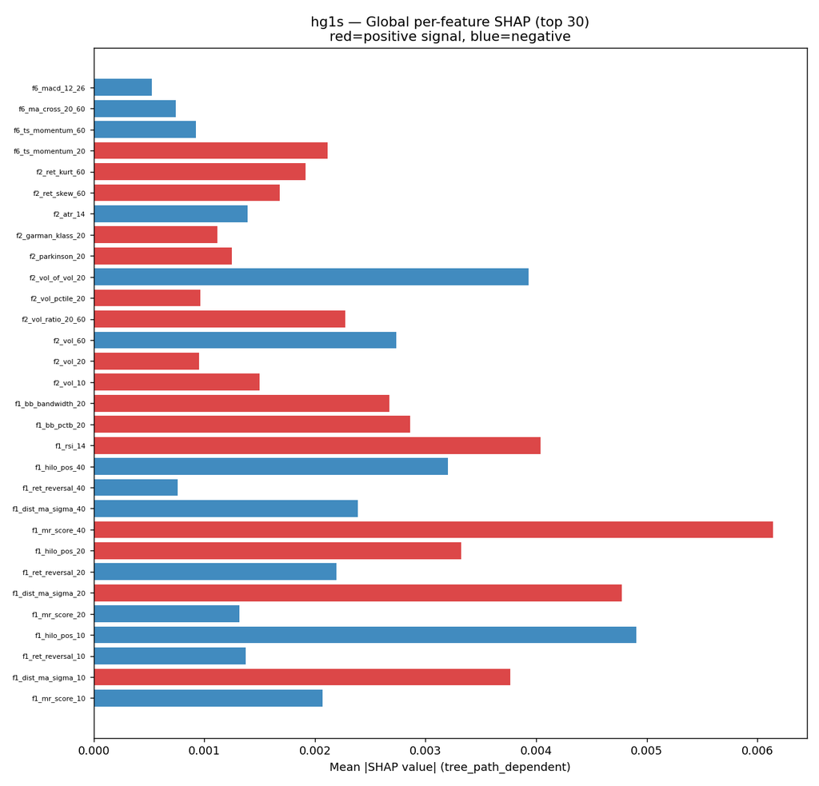

Top features by |SHAP|

| feature | shap_magnitude | shap_signed | mdi |
| --- | --- | --- | --- |
| f1_mr_score_40 | 0.0061 | 0.0004 | 0.0258 |
| f12_mra_energy_D1 | 0.0055 | -0.0014 | 0.0314 |
| f1_hilo_pos_10 | 0.0049 | -0.0003 | 0.0307 |
| f1_dist_ma_sigma_20 | 0.0048 | 0.0016 | 0.0259 |
| f12_mra_energy_D4 | 0.0046 | 0.0006 | 0.0225 |
| f1_rsi_14 | 0.0040 | 0.0002 | 0.0215 |
| f2_vol_of_vol_20 | 0.0039 | -0.0014 | 0.0171 |
| f11_skew_z | 0.0039 | 0.0008 | 0.0201 |
| f1_dist_ma_sigma_10 | 0.0038 | 0.0002 | 0.0245 |
| f11_gasoline_stock_surprise | 0.0037 | -0.0000 | 0.0195 |
| f11_dxy_z | 0.0034 | -0.0003 | 0.0161 |
| f1_hilo_pos_20 | 0.0033 | 0.0001 | 0.0203 |
| f1_hilo_pos_40 | 0.0032 | -0.0001 | 0.0181 |
| f11_dist_stock_surprise | 0.0031 | 0.0002 | 0.0142 |
| f11_copper_stock_z | 0.0031 | -0.0004 | 0.0145 |

Platinum (PL) — `pl1s`

| instrument | asset_class | group | family | model_type | auc_mean | auc_std | lower_ci | signal | n_folds | n_sig_clusters |
| --- | --- | --- | --- | --- | --- | --- | --- | --- | --- | --- |
| pl1s | metals | precious | tree | rf | 0.5697 | 0.0301 | 0.5396 | True | 15 | 2 |

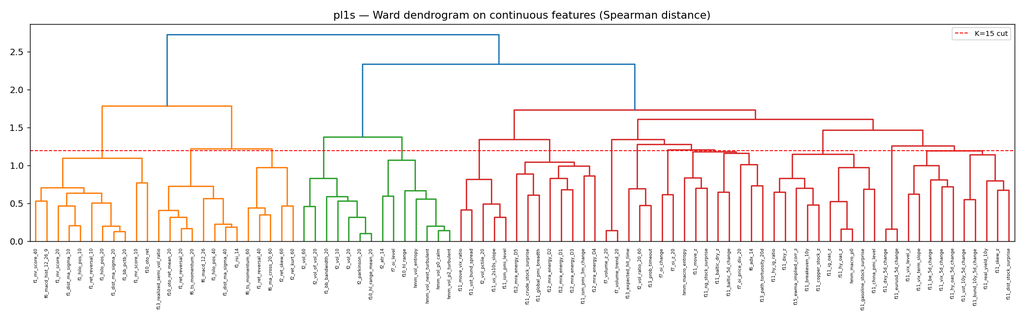

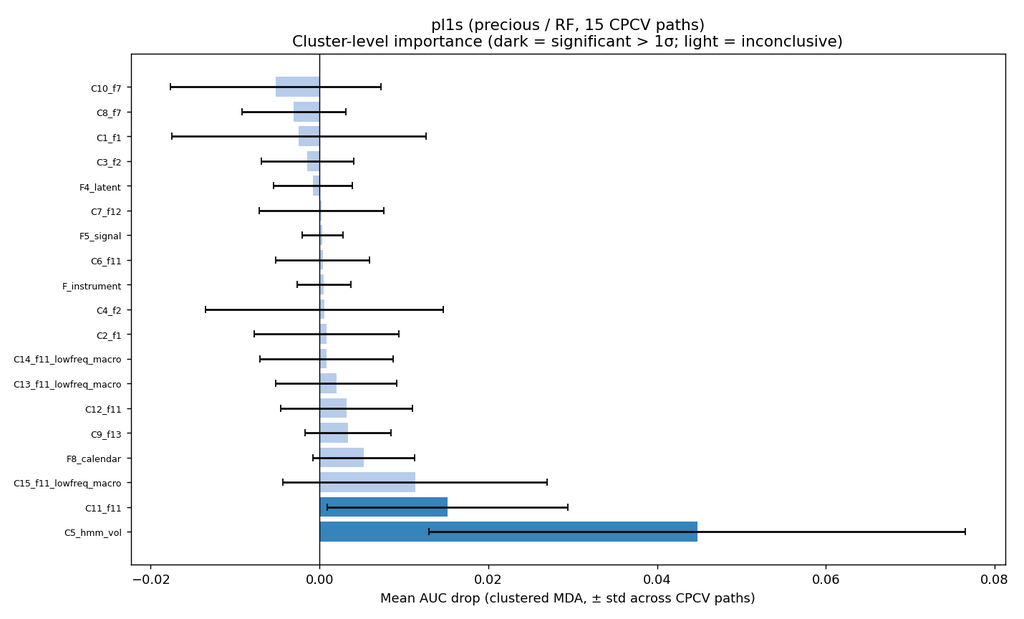

Top clusters by mean decrease in accuracy

| cluster | mean_drop | std_drop | significant |
| --- | --- | --- | --- |
| C5_hmm_vol | 0.0447 | 0.0318 | True |
| C11_f11 | 0.0152 | 0.0142 | True |
| C15_f11_lowfreq_macro | 0.0113 | 0.0157 | False |
| F8_calendar | 0.0053 | 0.0060 | False |
| C9_f13 | 0.0034 | 0.0051 | False |
| C12_f11 | 0.0032 | 0.0078 | False |
| C13_f11_lowfreq_macro | 0.0020 | 0.0072 | False |
| C14_f11_lowfreq_macro | 0.0009 | 0.0079 | False |

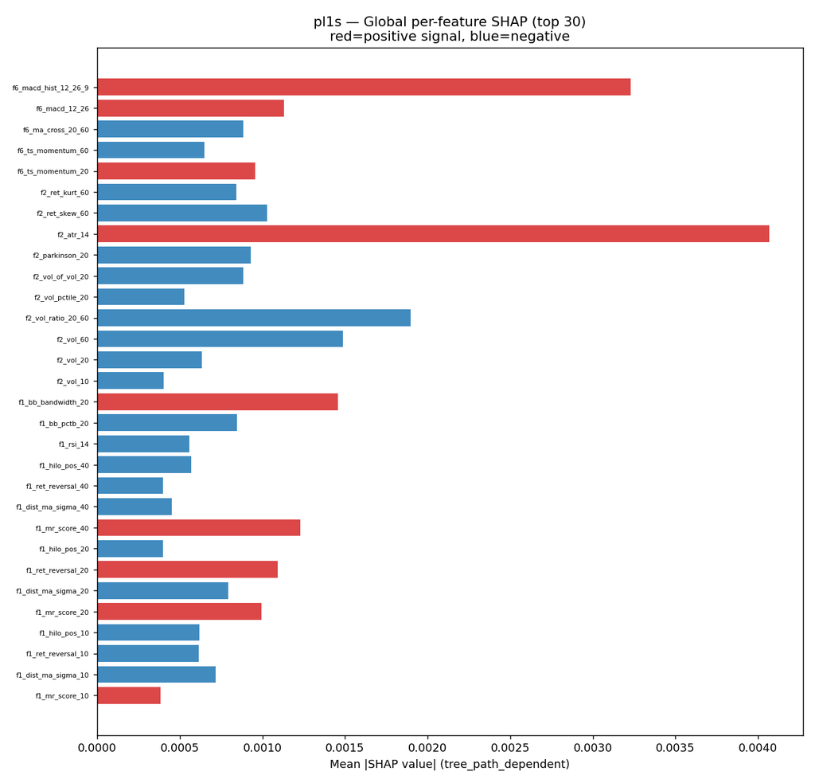

Top features by |SHAP|

| feature | shap_magnitude | shap_signed | mdi |
| --- | --- | --- | --- |
| f6_adx_14 | 0.0072 | 0.0038 | 0.0307 |
| hmm_vol_p0_calm | 0.0069 | 0.0039 | 0.0432 |
| hmm_vol_next_turbulent | 0.0066 | 0.0039 | 0.0463 |
| hmm_vol_p2_turbulent | 0.0063 | 0.0038 | 0.0427 |
| f2_atr_14 | 0.0041 | 0.0039 | 0.0301 |
| f11_ust_10y_5d_change | 0.0038 | -0.0005 | 0.0219 |
| f6_macd_hist_12_26_9 | 0.0032 | 0.0013 | 0.0226 |
| f7_oi_z_20 | 0.0025 | -0.0001 | 0.0172 |
| hmm_vol_entropy | 0.0024 | 0.0007 | 0.0278 |
| f11_eurusd_5d_change | 0.0024 | -0.0001 | 0.0206 |
| f11_copper_stock_z | 0.0022 | 0.0013 | 0.0109 |
| f11_dist_stock_surprise | 0.0022 | -0.0003 | 0.0122 |
| f11_bund_10y_5d_change | 0.0022 | -0.0002 | 0.0168 |
| f4_pc1 | 0.0020 | -0.0004 | 0.0164 |
| f4_pc2 | 0.0020 | 0.0009 | 0.0187 |

```python
imp = OUT / "importance"
sel = load(OUT / "model_comparison/selection_table.csv")
model_of = dict(zip(sel.get("instrument", []), sel.get("best_model", []))) if not sel.empty else {}

for inst in INSTS:
    d = imp / inst
    display(Markdown(f"### {NAMES[inst]} — `{inst}`"))
    cm = load(d / "champion_meta.csv")
    if not cm.empty:
        table(cm)
    show(d / "dendrogram.png", width=900)
    show(d / "clustered_mda_chart.png", width=820)
    mda = load(d / "clustered_mda_full.csv")
    if not mda.empty:
        table(mda.head(8), caption="Top clusters by mean decrease in accuracy")
    coef_png = d / "global_coef_chart.png"
    if str(model_of.get(inst, "")) == "logistic" and coef_png.exists():
        show(coef_png, width=820)
        table(load(d / "global_coef_summary.csv").head(15), caption="Top logistic coefficients")
    else:
        show(d / "global_shap_chart.png", width=820)
        table(load(d / "global_shap_summary.csv").head(15), caption="Top features by |SHAP|")
```

## 7. Strategy — pooled portfolio and per-class attribution

There is a single backtest, not one per class. The live strategy is one volatility-targeted, equally-weighted book over all eleven contracts: an EWMA(60) volatility estimate scales each position to a 10% annualised target, leverage is capped, returns lag the weights by a day, and Grinold-Kahn costs (a 2bp half-spread plus 10bp of turnover) are charged. The conventions are recorded in `results/strategy_eval/eval_summary.md`. Method A follows every signal; Method B trades only when the calibrated metamodel probability exceeds one half.

The headline table and cumulative-return figures below are the **pooled** result. The per-class table that follows is an **attribution** — this class's slice of the shared book — and not a standalone per-class Sharpe; with one pooled portfolio the instruments cannot be isolated into independent backtests.

Pooled portfolio — OOS headline (eval_summary.csv)

| Metric | A Benchmark | B all_or_nothing | B SOPS |
| --- | --- | --- | --- |
| Ann return | +8.62% | +4.65% | +4.65% |
| Ann vol | 6.10% | 2.88% | 2.88% |
| Sharpe | 1.412 | 1.614 | 1.614 |
| t-stat | 1.19 | 1.36 | 1.36 |
| SR 95% CI low | -1.559 | -1.286 | -1.286 |
| SR 95% CI high | 3.750 | 3.821 | 3.821 |
| PSR(SR*=0) | 0.861 | 0.899 | 0.899 |
| Max DD | -3.42% | -1.49% | -1.49% |
| Total cost (bps) | 416.1 | 188.4 | 188.4 |
| Annual turnover | 48.28 | 21.86 | 21.86 |
| Breakeven ½-spread | 17.8 bps | 21.3 bps | 21.3 bps |
| Events taken | 100% | 54% | 54% |

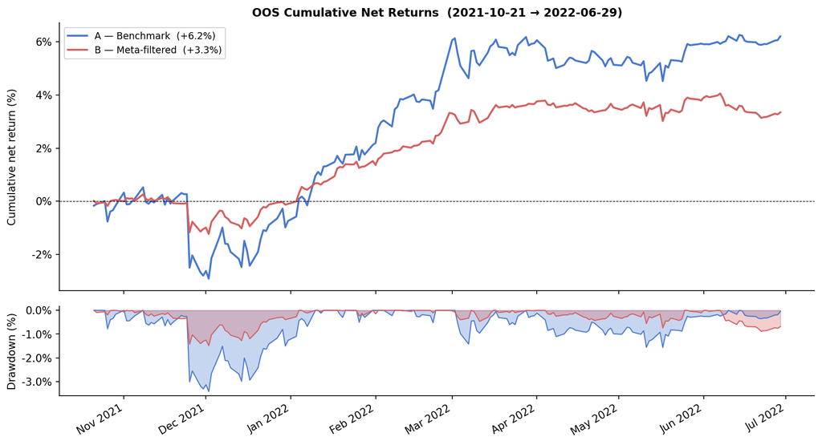

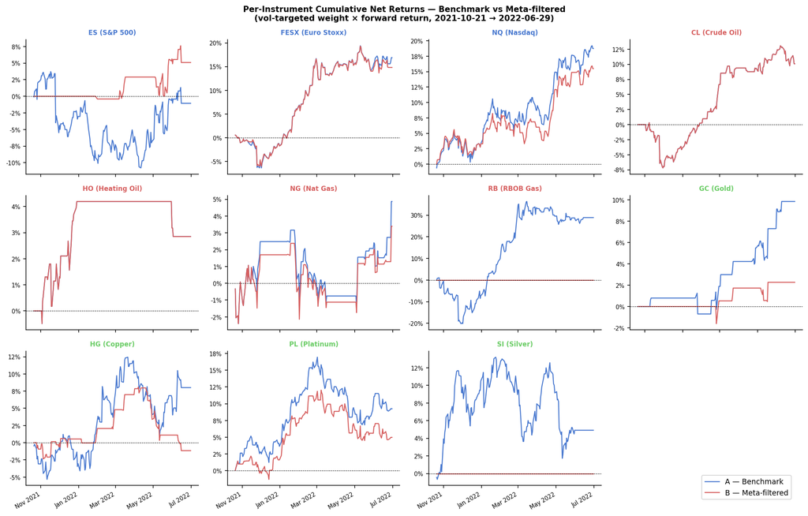

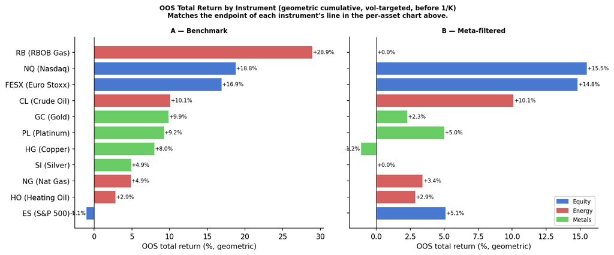

Metals — attribution within the pooled book (metamodel_predictions.csv)

| instrument | n_events | events_taken | mean_calib_proba | label1_share | hit_rate_taken |
| --- | --- | --- | --- | --- | --- |
| gc1s | 23.0000 | 7.0000 | 0.4458 | 0.6522 | 0.5714 |
| si1s | 144.0000 | 0.0000 | 0.3570 | 0.4722 | nan |
| hg1s | 164.0000 | 50.0000 | 0.4586 | 0.3841 | 0.3200 |
| pl1s | 148.0000 | 119.0000 | 0.5110 | 0.5541 | 0.5462 |

```python
se = RESULTS / "strategy_eval"
table(load(se / "eval_summary.csv"), caption="Pooled portfolio — OOS headline (eval_summary.csv)")
show(se / "cumulative_returns.png", width=860)
show(se / "per_asset_cumulative_returns.png", width=860)
show(se / "per_instrument_contribution.png", width=860)

# --- Per-class attribution within the pooled 1/K book (with numeric guards) ---
preds = load(OUT / "metamodel_predictions.csv")
assert not preds.empty, "metamodel_predictions.csv missing"
assert preds["calibrated_proba"].between(0, 1).all(), "calibrated_proba outside [0, 1]"
assert set(INSTS) <= set(preds["instrument"].unique()), "class instruments absent from predictions"

cls = preds[preds["instrument"].isin(INSTS)].copy()
cls["taken"] = cls["calibrated_proba"] > 0.5
attr = (cls.groupby("instrument")
           .apply(lambda g: pd.Series({
               "n_events": len(g),
               "events_taken": int(g["taken"].sum()),
               "mean_calib_proba": g["calibrated_proba"].mean(),
               "label1_share": g["bin"].mean(),
               "hit_rate_taken": g.loc[g["taken"], "bin"].mean() if g["taken"].any() else float("nan"),
           }), include_groups=False)
           .reindex(INSTS).reset_index())
assert (attr["events_taken"] <= attr["n_events"]).all(), "events_taken exceeds n_events"
table(attr, caption=f"{CLASS.title()} — attribution within the pooled book (metamodel_predictions.csv)")
```

## References

- López de Prado, M. (2018) *Advances in Financial Machine Learning*. Hoboken, NJ, Wiley. [Triple-barrier labelling ch. 3; average uniqueness ch. 4; purged and combinatorial cross-validation ch. 7.]
- Project methodology notes (this repository): `reports/harry/00-context.md`, `01-signal-direction.md`, `02-labels.md`, `03-features.md`, `03-6-macro-features.md`, and `reports/missing-data-report.md`.
- Strategy conventions: `results/strategy_eval/eval_summary.md` (StrategyWeights lecture, slides 38–43).
- Course materials: *Systematic Trading Strategies with Machine Learning* (T3.03), lectures L1–L8.